# Network Diagram

Jong-June Jeon

May, 2018

## 학습주안점

- 그래프 시각화에 적용할 수 있는 함수의 입력형식을 이해한다.

### Library

```r
if(!require(networkD3)){install.packages("networkD3"); library(networkD3)}
if(!require(igraph)){install.packages("igraph"); library(igraph)}
if(!require(reshape2)){install.packages("reshape2"); library(reshape2)}
```

네트워크 시각화를 위한 라이브러리 호출

## SimpleNetwork

- SimpleNetwork 는 networkD3의 함수로서 D3 force directed network graph를 생성해준다.
- force directed network graph는 그래프의 노드를 2 차원 또는 3 차원 공간에 배치하여 모든 edge의 길이가 거의 같고 가능한 한 cross edge가 거의 없도록 만들어준다.

## SimpleNetwork

```r
src <- c("A", "A", "A", "A",
         "B", "B", "C", "C", "D")
target <- c("B", "C", "D", "J",
            "E", "F", "G", "H", "I")
networkData <- data.frame(src, target)
head(networkData)
```

```
##   src target
## 1   A      B
## 2   A      C
## 3   A      D
## 4   A      J
## 5   B      E
## 6   B      F
```

## SimpleNetwork

```r
networkD3::simpleNetwork(networkData, fontSize = 15, zoom = T)
```

[interactive chart not shown]

## ForceNetwork

```r
data(MisLinks)
head(MisLinks)
```

```
##   source target value
## 1      1      0     1
## 2      2      0     8
## 3      3      0    10
## 4      3      2     6
## 5      4      0     1
## 6      5      0     1
```

Network plot을 그리기 위해서 필요한 Links 데이터  
- 시작점을 source로, 도착점을 target 으로 표기  
- value는 시작점과 도착점을 잇는 숫자형 변수

## ForceNetwork

```r
data(MisNodes)
head(MisNodes)
```

```
##              name group size
## 1          Myriel     1   15
## 2        Napoleon     1   20
## 3 Mlle.Baptistine     1   23
## 4    Mme.Magloire     1   30
## 5    CountessdeLo     1   11
## 6        Geborand     1    9
```

Network plot을 그리기 위해서 필요한 Nodes 데이터  
- 각 점들에 관한 데이터가 저장  
- 점의 이름과, 군집, size가 저장되어 있는 데이터

## ForceNetwork

```r
forceNetwork(Links = MisLinks, Nodes = MisNodes,
             Source = "source", Target = "target",
             Value = "value", arrows = T,
             Group = "group", opacity = 0.8, zoom = TRUE)
```

- Link 데이터와 Node데이터의 시작점, 도착점, 값 등을 입력
- arrows option을 이용하여 방향표현 가능
- source option : start node
- target option : end node
- group option : group별 색상을 다르게 줌
- value option : value에 따라 화살표의 두깨를 조절해줌

## ForceNetwork

[interactive chart not shown]

## SankeyNetwork

```r
sankeyNetwork(Links = MisLinks, Nodes = MisNodes,
             Source = "source", Target = "target",
             Value = "value", NodeID = "name",
             fontSize = 12, nodeWidth = 18)
```

- Link 데이터와 Node데이터의 시작점, 도착점, 값 등을 입력
- NodeID option : node에 이름 표시

## SankeyNetwork

[interactive chart not shown]

## SankeyNetwork Example

## 데이터 셋

### 설명

- 2014년부터 2017년까지의 https://www.nature.com/ 에서 "machine learning"이라는 키워드를 가진 documnet 2516편
- https://www.ieee.org/ 에 있는 dictionary에 있는 단어 사용

### 구조

- data : 년도 별 documnet에 나타난 단어의 빈도
- n_gram : 각각 documnet가 가지는 단어 집합
- date : documnet가 게시된 날짜
- conf_data : 단어, 년도별 confidence 데이터

## 라이브러리

- 사용할 패키지 및 데이터 셋 호출

```r
if(!require(data.table)){install.packages("data.table");
  library(data.table)}
if(!require(dplyr)){install.packages("dplyr"); library(dplyr)}

setwd("???") # dataset이 존재하는 library지정
load("data_list.Rdata")
```

## 년도별 문서 갯수

- 2014년 : "machine learning"에 관련 논문에 대해 몇편 존재하지 않음
- 2017년 : 데이터 수집 기간이 2017년 중간까지임.

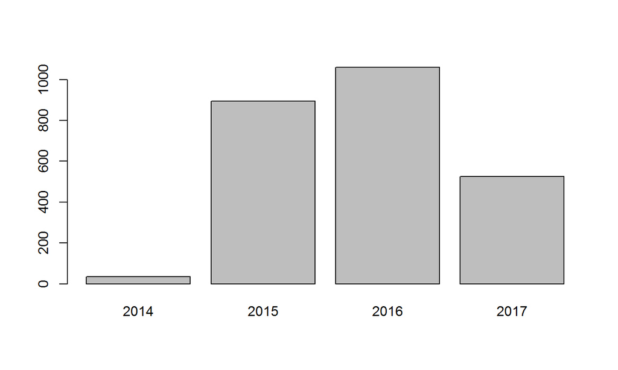

```r
barplot(table(data_list$date))
```

## confidence plot

- confidence (신뢰도)
  - 사건 A와 사건 B가 동시에 발생할 확률 대비 A가 발생할 확률

$$conf(A \Rightarrow B) = \frac{P(A \bigcap B)}{P(A)}$$

- 각 년도별 machine learning과 관련된 documnet내에 특정 단어의 빈도 대비 machine learning과 관련된 documnet 빈도로 계산
- 2014년 ~ 2016년까지의 confidence 평균을 구해 2017년의 단어들의 confidence 비율 파악
- 주의 : 2014년 ~ 2016년까지 없던 단어가 2017년에 1번이라도 나오면 `inf`값을 가지게 된다.

## confidence plot

- confidence plot을 그리기 위한 핸들링

```r
conf_result = data_list$conf_data
mean_conf = apply(conf_result[,2:4],1,mean)
conf_result$increasing_rate = conf_result[,5] / mean_conf
attach(conf_result)
text_conf = conf_result[c(which(is.finite(increasing_rate) &
                  increasing_rate > 20), which(mean_conf > 0.3)),]
loc_conf = mean_conf[c(which(is.finite(increasing_rate) &
                  increasing_rate > 20), which(mean_conf > 0.3))]
```

- apply를 이용하여 행별 평균을 구해 저장
- 2017년 결과를 행별로 비율을 계산해 저장
- text_conf, loc_conf : 그래프에 쓸 글씨 및 위치 지정

## confidence plot

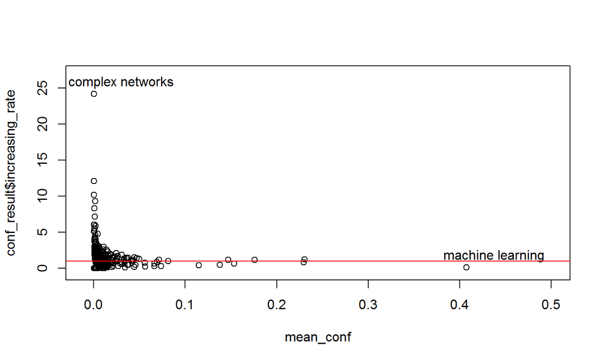

```r
plot(mean_conf, conf_result$increasing_rate, ylim = c(-0.5, 27),
     xlim = c(-0.01, 0.5))
text(loc_conf + 0.03, text_conf$increasing_rate,
     labels = text_conf$word, cex = 1, pos = 3)
abline(h = 1, col = 'red')
```

## confidence plot

- 2가지 단어에 대해 살펴보자.
  - machine learning : 2014년 ~ 2016년의 평균 신뢰도는 0.4로써 가장 높은 편이다. 그러나 비율은 1보다 작은 값을 가진다. 이는 2016년까지는 높은 빈도가 나왔고, 2017년에는 평균보다 더 낮은 빈도로 나온다는 의미이다.
  - complex networks : 2014년 ~ 2016년의 평균 신뢰도는 거의 0에 가깝다. 그러나 비율은 가장 큰 25에 가까운 값을 관측할 수 있다. 즉, 2016년까지는 빈도가 거의 없었지만, 2017년부터 빈도가 급증한 경우이다.

## Term-Document-matrix

- 데이터 구조 변경 : termDocumentmatrix를 생성한다.
  - 단어와 documnet간의 포함관계를 나타내는 메트릭스이며, sparse한 메트릭스가 생성된다.

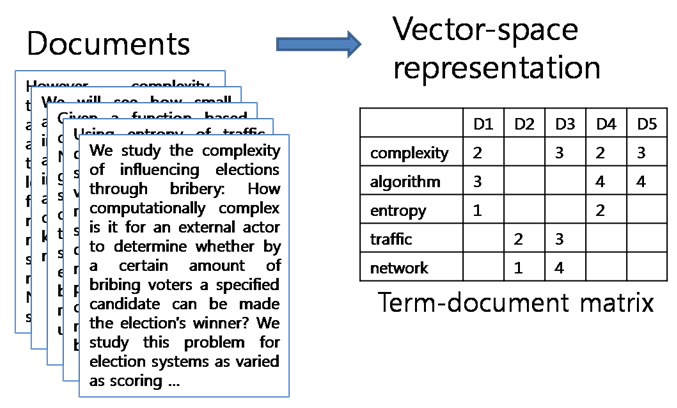

## Term-Document-matrix

```r
doc_list = data_list$n_gram
uniq_words = unique(do.call('c', doc_list))
occur_vec_list = lapply(doc_list, function(x) uniq_words %in% x)

dtm_mat = do.call('rbind', occur_vec_list)
colnames(dtm_mat) = uniq_words
```

- 각각의 documnet에 단어가 포함되어 있으면 1, 아니면 0을 할당하는 메트릭스 생성
  - dtm_mat으로 저장함.
- dtm_mat의 column는 단어, row는 documnt이므로 column이름을 단어로 할당

## Term-Document-matrix

```r
refined_dtm_mat = dtm_mat[, colSums(dtm_mat) != 0]
refined_dtm_mat = refined_dtm_mat[rowSums(refined_dtm_mat) != 0,]
```

## cooccur_mat

```r
cooccur_mat = t(refined_dtm_mat) %*% refined_dtm_mat
cooccur_mat[1:4, 1:4]
```

```
##              media minimization current correlation
## media           42            2       4           6
## minimization     2           66       2           5
## current          4            2     199          10
## correlation      6            5      10         133
```

- cooccur matrix 생성
  - documnet내에 2개의 단어의 쌍의 빈도를 표현하는 메트릭스

## cooccur_mat

- 메트릭스의 크기가 너무 크기 때문에 단어에 기준을 주어 크기를 줄여서 그린다.
  - 방법1 : 대각 원소를 이용하여 줄인다. 대각원소는 그 단어의 빈도를 의미 하므로 그 빈도가 작은 단어를 삭제한다.
  - 방법2 : 앞서 구한 confidence를 이용한다. confidence의 비율 증가가 상대적으로 큰 단어들을 가져온다.

```r
# 방법 1
inx = diag(cooccur_mat) >= 150
cooccur_plot_mat1 = cooccur_mat[inx, inx]

# 방법 2
idx = which(conf_result$increasing_rate[
  which(is.finite(conf_result$increasing_rate))] >= 5)
cooccur_plot_mat2 = cooccur_mat[idx, idx]
```

- diag : matrix의 대각원소들만 뽑아주는 함수

## sankey plot

- sankey plot을 그리기 위한 함수들

```r
g = graph.adjacency(cooccur_plot_mat1, weighted = T, mode = 'undirected')
g = simplify(g)
wc = cluster_walktrap(g)
members = membership(wc)
network_list = igraph_to_networkD3(g, group = members)
```

- graph.adjacency : 행과 관련 있는 열들을 list로 묶어줌
- simplify : 행과 같은 index인 열들을 제거함
- cluster_walktrap : group을 지정함
- membership : group의 index를 지정
- igraph_to_networkD3 : sankey plot에 맞게 데이터 셋을 변환해줌

## sankey plot

```r
sankeyNetwork(Links = network_list$links, Nodes = network_list$nodes,
              Source = "source", Target = "target",
              Value = "value", NodeID = "name",
              units = "TWh", fontSize = 18, nodeWidth = 30)
```

[interactive chart not shown]

## Circular Plot

```r
if(!require(circlize)){install.packages("circlize"); library(circlize)}
name=c(3,10,10,3,6,7,8,3,6,1,2,2,6,10,2,3,3,10,4,5,9,10)
feature=paste("feature ", c(1,1,2,2,2,2,2,3,3,3,3,3,3,3,4,4,4,4,5,5,5,5),
              sep="")
dat <- data.frame(name,feature)
dat <- table(name, feature)
head(dat,4)
```

```
##     feature
## name feature 1 feature 2 feature 3 feature 4 feature 5
##    1         0         0         1         0         0
##    2         0         0         2         1         0
##    3         1         1         1         2         0
##    4         0         0         0         0         1
```

## Circular Plot

### chord diagrame

- 코드 다이어그램은 행렬의 데이터 간 상호 관계를 표시
- 데이터: 일반적으로 원을 중심으로 방사형으로 배열되며,데이터를 연결하는 호를 이용하여 데이터 요소 간의 관계를 표시함.

## Circular Plot

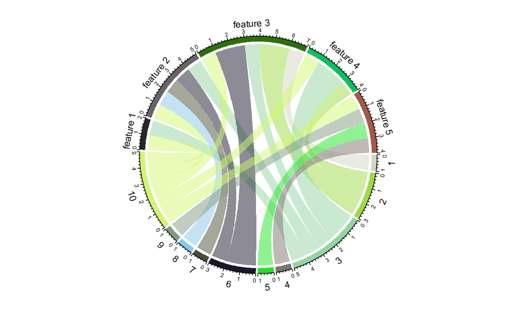

```r
chordDiagram(as.data.frame(dat), transparency = 0.5)
```

## Circular Plot

```r
if(!require(chorddiag)){devtools::install_github("mattflor/chorddiag");
  library(chorddiag)}
if(!require(RColorBrewer)){install.packages("RColorBrewer")}
```

- 사용할 패키지

## Circular Plot

```r
doc_list = data_list$n_gram
table_list = lapply(doc_list, table)[1:3]
table_name = unique(unlist(do.call("c", doc_list[1:3] )))
names(table_list) = paste0("doc_", 1:3)

table_list = lapply(table_list, function(x){
    word_table = rep(0, length = length(uniq_words))
    word_table = ifelse(uniq_words %in% names(x), x, 0)
  }
)

table_list = do.call("rbind", table_list)

refined_table_list = t(table_list[, apply(table_list, 2, sum) != 0])
rownames(refined_table_list) = table_name
```

## Circular Plot

```r
groupColors <- brewer.pal(3, "Set3")

chorddiag(refined_table_list
          , groupColors = groupColors,  type = "bipartite", tickInterval = 3
          ,groupnameFontsize = 15)
```

[interactive chart not shown]